# Julijin paket Flux

Julijin paket Flux je namenjen mašinskom učenju, pre svega upotrebi veštačkih neuronskih mreža (VNM). U potpunosti je implementiran u Juliji i sadrži "laganu" abstrakciju Julijine podrške za GPU i automatsko diferenciranje. Neki od osnovnih principa paketa su: da radi očigledno i brzo na osnovu matematičkih opisa/zapisa, da bude lako proširiv i da sarađuje sa drugim nepovezanim Julija bibliotekama (a ne da ih kopira, poput rada sa slikama, rešavanja differencijalnih jednačina).

Ideja ovog teksta je da ilustruje neke od primena Flux paketa na jednostavnim primerima bez nastojanja da se prikaže kompletan pregled njegovih mogućnosti, niti da se mogućnosti porede sa drugim paketima.

Za početak se uvodi jedan neuron sa dva ulaza i njegova aktivaciona funkcija je linearna.

```julia
using Flux

neuron = Dense(2 => 1)
```

```
Dense(2 => 1)       # 3 parameters
```

Funkcijom *Dense* je napravljen jedan sloj neuronske mreže gde se 2 ulaza prenose na 1 izlaz - te ona ima jedan neuron. Težine i bijas se postavljaju na početne vrednosti.

```julia
neuron.weight, neuron.bias
```

```
(Float32[-0.268834 -1.3351339], Float32[0.0])
```

Pretpostavimo da pravimo model gde se izlaz menja kao funkcija *f(x)*.

```julia
f(x) = 2x[1] - 3x[2] + 4;
```

Da bi se neuron obučio potrebno je formirati obučavajući skup. Na primer, pomoću narednom koda.

```julia
opseg = -5.0 : 1.0 : 5.0;
n = length(opseg);
x = zeros(Float32, 2, n*n); y = zeros(Float32, 1, n*n);
k = 0;
for x1 in opseg
    for x2 in opseg
        global k += 1;
        x[:,k] = [x1; x2];
        y[k] = f(x[:,k]);
    end
end
```

Izlaz neobučenog neurona ne odgovara očekivanim izlazima.

```julia
o = neuron(x)
```

```
1×121 Matrix{Float32}:
 8.01984  6.68471  5.34957  4.01444  2.6793  …  -5.34957  -6.68471  -8.0198
4
```

Da bi izlazi neurona odgovarali očekivanim, potrebno je obučiti neuronsku mrežu (u ovom slučaju jedan neuron). Jedna epoha u obučavanju se realizuje pozivom funkcije *train!*.

```julia
greška(model, x, y) = Flux.mse( model(x), y );
opt = Descent(0.01);
Flux.train!(greška, neuron, [(x,y)], opt)
greška(neuron,x,y), neuron.weight, neuron.bias
```

```
(66.050476f0, Float32[0.18493271 -1.668107], Float32[0.07999999])
```

Ovde je upotrebljen gradijentni algoritam (metoda najstrmijeg pada sa koeficijentom brzine obučavanja 0.01) za minimizaciju funkcije cilja *greška*, računate kao srednja kvadratna greška (*mse - mean squared error*) odstupanja odziva neurona *neuron(x)* u odnosu na vrednosti iz obučavajućeg skupa *y*. Nakon jedne epohe, funkcija cilja (tj. greška) se neznatno smanjila i parametri neurona su još uvek daleko od potrebnih.

Međutim, nakon dodatnih opoha obučavanja:

```julia
for epoha in 1:200
    Flux.train!(greška, neuron, [(x,y)], opt)
end
```

dobija se obučen neuron gde je posmatrana greška mala, a paramteri neurona odgovaraju očekivanim vrednostima funkcije *f*.

```julia
J = greška(neuron, x, y);
J, neuron.weight, neuron.bias
```

```
(0.004753388f0, Float32[1.9999999 -2.9999995], Float32[3.9310553])
```

Jedna od pogodnosti Flux paketa je "automatsko" izračunavanje gradijenata bez eksplicitnog definisanja funkcija izvoda (izvoda funkcije cilja po parametrima: težinama i bijasima u neuronima). Ovo je primenljivo i na mreže sa većim brojem slojeva.

Radi ilustracije, sledeći kod definiše funkciju *f(x,y,z)* tri parametra, a Flux funkcija *gradient* generiše programski kod za iračunavanje parcijalnih izvoda *f* po parametrima *x*, *z* i *z*. Konačno, za konkretne vrednosti *x=1*, *z=2* i *z=3* su izračunate vrednosti parcijalnih izvoda.

```julia
f(x, y, z) = x^2 + x*y^2 + z^2
a(x,y,z) = gradient(f, x, y, z)
a(1, 2, 3)
```

```
(6.0, 4.0, 6.0)
```

Funkcija *gradient* se poziva unutar *train!* i upotrebljava se za obuku neuronske mreže, gde se generiše Julija kod za gradijent funkcije cilja (u gornjem primeru *greška*) po parametrima mreže.

## Primer: XOR problem sa dva sloja neurona

Na sličan način, može se obučiti neuronska mreža da "prepoznaje" XOR problem 2 ulaza (ovde je "istina" označena sa 1, a "laž" sa -1). Upotrebljava se neuronska mreža sa 2 sloja. Skriveni sloj ima 2 neurona sa sigmoid aktivacionim funkcijama, i jedan neuron je u izlaznom sloju i njegova aktivaciona funkcija je lilnearna. Da bi se takva arhitektura mreže opisala koriste se funkcija *Dense* za opis sloja neurona i funkcija *Chain* da bi se povezali slojevi u neuronsku mrežu. *Dense* modeluje *fully connected* sloj neurona (svi ulazi su povezani na sve neurone), a parametri funkcije su: broj ulaza u sloj, broj neurona i aktivaciona funkcija. Podrazumevana aktivaciona funkcija je linearna, pa se ne navodi u definiciji drugog sloja neurona (*sloj2*).

Za obuku mreže se koristi *Momentum* funkcija koja implementira gradijentni postupak "sa inercijom". Njeni parametri su koeficijent brzine obučavanja (0.1) i memonetum faktor (0.8).

Sama obuka se sprovodi pozivom funkcije *train!* gde se u pozivu funkcije prosleđuju: funkcija cilja *greška*, sama mreža, obučavajući skup [(*x*, *y*)], i algoritam koji se koristi za obuku *opt* (tj. minimizaciju funkcije cilja). Obuka se ovde vrši kroz 100 epoha, a na kraju se prikazuje odziv obučene mreže, koji je očito jednak željenim izlazima.

```julia
using Flux, Random
Random.seed!(1234);

x = [-1  1 -1  1
     -1 -1  1  1]     # ulazi
y = [-1  1  1 -1]     # izlazi XOR

sloj1 = Dense(2 => 2, tanh)
sloj2 = Dense(2 => 1)
mreža = Chain( sloj1, sloj2 )

greška(model, x, y) = Flux.mse( model(x), y );
opt = Flux.setup(Flux.Momentum(0.1, 0.8), mreža)

for epoha in 1:100
    Flux.train!(greška, mreža, [(x,y)], opt)
    if rem(epoha, 10) == 0
        println("it=", epoha, " J=", greška(mreža, x, y))
    end
end
mreža(x)
```

```
it=10 J=0.9734658
it=20 J=0.6123824
it=30 J=0.0007543005
it=40 J=0.006321196
it=50 J=0.00049239723
it=60 J=4.63394e-6
it=70 J=8.965238e-6
it=80 J=4.1141692e-7
it=90 J=1.8417445e-8
it=100 J=1.1677361e-8
1×4 Matrix{Float32}:
 -1.00007  1.00012  1.00015  -1.00006
```

Flux paket ima definisane brojne tipove slojeva neurona: *Dense*, *RNN*, *Maxout*, *Conv*, *MaxPool* itd, kao i optimizacione algoritme implementirane u funkcijama: *Descent*, *Momentum*, *ADAM*, *AdaMax*, i sl.

## Primer: funkcija jedne promenljive

U ovom primeru prvo se definiše obučavajući skup koga čine nizovi *X* i *Y*, a zatim se definiše mreža sa 20 neurona u skrivenom sloju (tipa tangensni sigmoid) i jednim neuronom na izlazu (linearan neuron).

```
it=1000 J=0.01771785952876694
it=2000 J=0.007026441750018643
it=3000 J=0.005261119907860048
it=4000 J=0.0045040709626870965
it=5000 J=0.0037229085522829707
it=6000 J=0.0028158470273514434
it=7000 J=0.0014202627529527388
it=8000 J=0.00042915707804270505
it=9000 J=7.525106348197513e-5
it=10000 J=1.720314423801834e-5
```

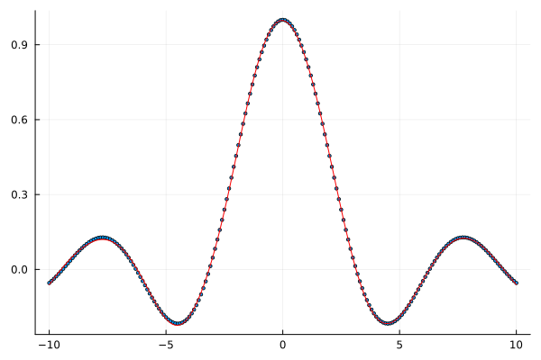

```julia
using Flux, Random, Plots
Random.seed!(1234);

f(x) = (x != 0.) ? sin(x)/x : 1.
X = collect(Float32, -10:0.1:10)'
Y = f.(X)

sloj1 = Dense(1 => 20, tanh)
sloj2 = Dense(20 => 1)
mreža = Chain(sloj1, sloj2)

greška(model, x, y) = Flux.mse( model(x), y );
opt = Flux.setup(Flux.ADAM(), mreža)

Jovi = []
for epoha in 1:10000
    Flux.train!(greška, mreža, [(X,Y)], opt)
    if rem(epoha, 1000) == 0
        j = greška(mreža, X, Y)
        push!(Jovi, j)
        println("it=", epoha, " J=", j)
    end
end
plot(Jovi, title = "Funkcija cilja tokom obuke - ADAM algoritam", xlabel="epohe", lab="")

plot(X',Y',marker=2, lw=:0, lab="")
plot!(X',mreža(X)', linecolor=:red, lw=1, lab="")
```

U prikazanom primeru obuka je trajala 10000 epoha, što je teško predvideti, a i proceniti da li je dovoljno. Stoga je pogodno obučavajući skup podeliti na sledeće podskupove:

- podskup koji se koriste za ažuriranje vrednosti parametara,
- kontrolni podskup na osnovu koga se računa greška tokom obuke, i
- testni podskup koji se ne koristi tokom obuke.

Pored definisanja ova tri podskupa, u narednom primeru je definisana neuronska mreža sa 3 sloja (radi ilustracije mogućnosti paketa).

```julia
using Flux, Random, Plots
Random.seed!(1234)

# definisanje obučavajućeg skupa
f(x) = (x != 0.) ? sin(x)/x : 1.
X = collect(Float32, -10:0.02:10)
sigma = 0.05
Y = f.(X) + randn(length(X))*sigma

# delovi uzoraka za obuku, test kraja obuke i test
procObuka = 0.8
procTest = 0.1
procKraj = 1 - procObuka - procTest

pomoc = rand(length(X))
selObuka = pomoc .<= procObuka
Xobuka, Yobuka = X[selObuka]', Y[selObuka]'
selKraj = procObuka .< pomoc .<= (procObuka + procKraj)
Xkraj, Ykraj = X[selKraj]', Y[selKraj]'
selTest = (procObuka + procKraj) .< pomoc
Xtest, Ytest = X[selTest]', Y[selTest]'

# definisanje mreže
sloj1 = Dense(1 => 10, tanh)
sloj2 = Dense(10 => 3, tanh)
sloj3 = Dense(3 => 1)
mreža = Chain( sloj1, sloj2, sloj3 )

greška(model, x, y) = Flux.mse( model(x), y );
opt = Flux.setup(Flux.ADAM(), mreža)

epsilon = (sigma*1.1)^2
ispisNa, grafikNa, maxEpoha = 1000, 100, 200000
epoha = 0
kraj = false
obukaOsa = []
obukaKriva = []
obukaKrajKriva = []
testKriva = []

while !kraj
    Flux.train!(greška, mreža, [(Xobuka, Yobuka)], opt)

    global epoha += 1
    if epoha > maxEpoha
        println("Dostignut maksimalan broj epoha")
        global kraj = true
    end

    ciljKraj = greška(mreža, Xkraj, Ykraj)       # test kraja na osnovu kontrolnog podskupa
    if ciljKraj < epsilon
        println(epoha, "  ", ciljKraj)
        global kraj = true
    elseif rem(epoha, ispisNa) == 0
        println(epoha, "  ", ciljKraj)
    end

    if rem(epoha, grafikNa) == 0 || kraj
        push!(obukaOsa, epoha)
        push!(obukaKriva, greška(mreža, Xobuka, Yobuka))
        push!(obukaKrajKriva, ciljKraj)
        push!(testKriva, greška(mreža, Xtest, Ytest))
    end
end
println("eps = ", epsilon)
```

```
1000  0.010336164384511723
2000  0.006549595543245669
3000  0.005649219432790116
4000  0.00458383234125884
4754  0.003023758747591417
eps = 0.0030250000000000008
```

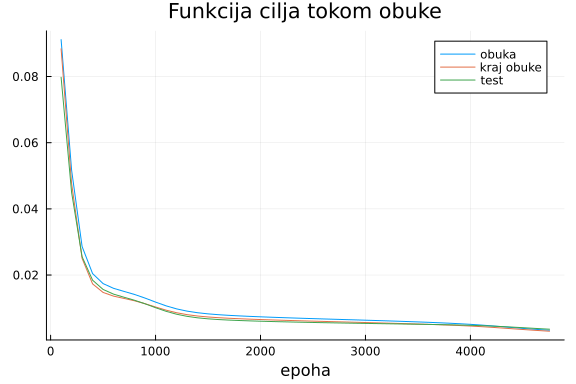

```julia
# grafikoni
plot(obukaOsa, [obukaKriva obukaKrajKriva testKriva],
            title="Funkcija cilja tokom obuke", xlabel="epoha", lab=["obuka" "kraj obuke" "test"])
```

Prethodni dijagram prikazuje promenu greške (funkcije cilja) tokom trajanja obuke, gde su prikazane greške računate za svaki od podskupova obučavajuće skupa.

Naredni dijagram prikazuje obučavajući skup i odziv obučene mreže.

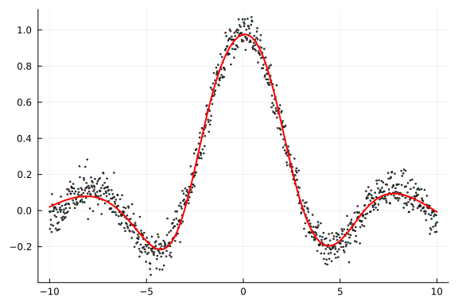

```julia
plot(X',Y',marker=1, lw=:0, lab="")
plot!(X,mreža(X')',linecolor=:red,lw=2,lab="")
```

## Primer: površ

Posmatra se matematička funkcija dve promenljive i od VNM se očekuje na nauči njeno mapiranje. Ovaj primer je zahtevniji i tipično se upotrebljava GPU za obuku. Tada je potrebno podatke i mrežu (zajedno sa autogenerisanim kodom) prebaciti u GPU, što se jednostavno postiže u Juliji upotrebom "... |> gpu". Ipak, prikazani kod ne upotrebljava GPU radi jednostavnosti.

```
5000  0.0023751534509786508
10000  0.00040752866512187814
15000  0.00022828032817377323
20000  0.00017573324032604858
25000  0.00013739765455186463
30000  0.00010456762487755958
30946  9.999955195709323e-5
```

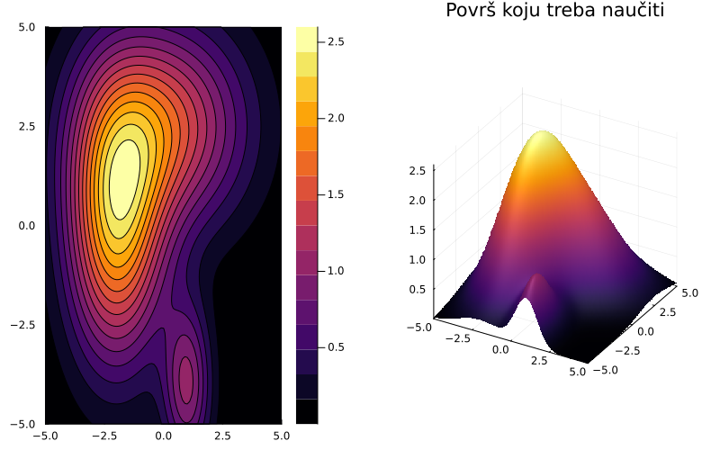

```julia
using Flux, Random, Plots
Random.seed!(1234);

x = -5:0.1:5
y = -5:0.1:5
f(x, y) = begin
        exp(-(x-1)^2-(.5*y+2)^2) + 2*exp(-(.5*x+1)^2-(.3*y)^2) + 1.5*exp(-(.3*x)^2-(0.4*y-1)^2)
    end
X = repeat(reshape(x, 1, :), length(y), 1)
Y = repeat(y, 1, length(x))
Z = map(f, X, Y)

Ul = [X[:]'; Y[:]'];
Izl = Z[:]';

sloj1 = Dense(2 => 100, tanh);
sloj2 = Dense(100 => 1);
mreža = Chain( sloj1, sloj2 );


greška(model, x, y) = Flux.mse( model(x), y );
opt = Flux.setup(Flux.AdaMax(), mreža)   # probati: Momentum(0.07,0.95) Momentum() ADAM() Descent(0.1)

for epoha in 1:50000
    Flux.train!(greška, mreža, [(Ul, Izl)], opt)

    J = greška(mreža, Ul, Izl)
    if rem(epoha, 5000) == 0 || J < 0.0001
        println(epoha, "  ", J)
        if J < 0.0001
            break
        end
    end
end

# grafički prikazi
p1 = contour(x, y, f, fill=true)
p2 = surface(x, y, f, title="Površ koju treba naučiti",
    camera=(30,30), legend=false, seriestype=:wireframe, size=[800,500]);
plot(p1, p2)
```

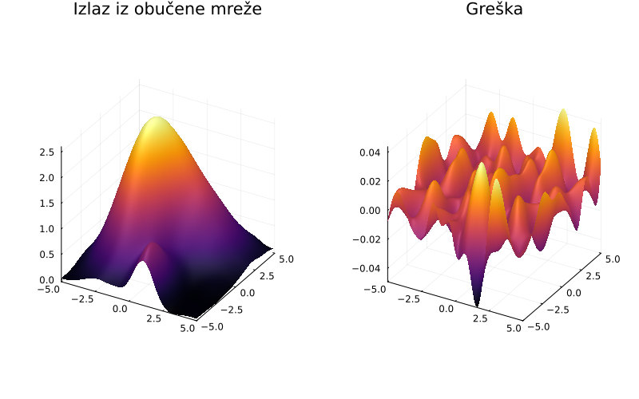

```julia
# još grafičkih prikaza
IzlM = mreža(Ul)    #|> cpu
p1 = surface(x, y, reshape(IzlM, length(x), length(y)), title="Izlaz iz obučene mreže",
    camera=(30,30), legend=false, seriestype=:wireframe, size=[800,500]);
p2 = surface(x, y, Z .- reshape(IzlM, length(x), length(y)), title="Greška",
    camera=(30,30), legend=false, seriestype=:wireframe, size=[800,500]);
plot(p1, p2)
```

## Primer 1 dinamičkog modela

U ovom primeru se upotrebljava neuronska mreža da nauči ponašanje ARX modela. Mreža se sastoji od jednog neurona sa linearnog aktivacionom funkcijom. Obučavajući skup je formiran na osnovu funkcije prenosa (dobijene vremenskom diskretizacijom sa periodom odabiranja *Ts*) koja je pobuđena pseudoslučajnim binarnim signalom. Na vrednosti izlaza modela koje su dobijene pozivom funkcije *lsim* (iz paketa *ControlSystems*) superponiran je beli čum (čija je standardna devijacija 0.001).

```julia
using ControlSystems, Random
Random.seed!(1234)

Ts = 0.02
m = tf(38.9, [1, 12.5]);
md = c2d(m, Ts);
# Diskretna funkcija prenosa W(z)=P(z)/Q(z):
#   P(z) = 0.6884 z^-1
#   Q(z) = 1 - 0.7788 z^-1
Tf = 20.
n = Int(Tf / Ts + 1)
u = (rand(n,1) .> 0.5) .- 0.5
t = 0:Ts:Tf
y,_,_ = lsim(md, u, t)
ysum = y + randn(1,n)*0.001

U = [u[1:end-1]'; ysum[1:end-1]']   # ulazi obučavajućeg skupa
Y = ysum[2:end]'                    # izlazi obučavajućeg skupa

sloj1 = Dense(2 => 1)                 # jedan linearan neuron
mreža = Chain( sloj1 )

greška(model, x, y) = Flux.mse( model(x), y );
opt = Flux.setup(Flux.AdaMax(), mreža)

for epoha in 1:5000
    Flux.train!(greška, mreža, [(U,Y)], opt)
    J = greška(mreža, U,Y)
    if rem(epoha, 1000) == 0 || J < 0.0001
        println(epoha, "  ", J)
        if J < 0.0001
            break
        end
    end
end

# ispis parametara obučene mreže
@show(mreža[1].weight, mreža[1].bias);
```

```
1000  0.0013640563800675133
1275  9.902112223792574e-5
(mreža[1]).weight = Float32[0.7040358 0.76780844]
(mreža[1]).bias = Float32[0.000989342]
```

Vrednosti parametara obučene mreže su bliske parametrima ARX modela (iz diskretne funkcije prenosa *md*). Te vrednosti nisu identične jer se obuka VNM vršila zašumljenim izlazom. Ideja primera je da se uoči kako jedan linearan neuron uspešno predstavlja ARX model.

## Primer 2 dinamičkog modela

U realizaciji, ovaj primer je veoma sličan prethodnom, ali se u suštini razlikuje jer je upotrebljen drugačiji model sistema. Radi se linearnom modelu (ARX) drugog reda, za razliku od prethodnog slučaja gde je model bio 1. reda. Posledica te razlike je veći broj parametara i oscilatoran karakter ponašanja modela.

```julia
Random.seed!(1234)

Ts = 0.1
m = tf(10.,[1., 1., 2.]);
md = c2d(m, Ts);
# Dobija se diskretna funkcija prenosa W(z)=P(z)/Q(z):
# P(z) = 0.04670995795866095 + 0.04829415180315344*z
# Q(z) = 0.9048374180359595 - 1.8858365960835966*z + 1.0*z^2

Tf = 2000.                  # krajnje vreme simulacije
n = Int(Tf / Ts + 1)        # broj odbiraka
u = (rand(n,1) .> 0.5) .- 0.5   # ulaz PRBS
t = 0:Ts:Tf                 # vreme
y,_,_ = lsim(md, u, t)      # izlaz
ysum = y + randn(1,n)*0.001  # izlaz sa šumom

U = [u[1:end-2]'; u[2:end-1]'; ysum[1:end-2]'; ysum[2:end-1]']
Y = ysum[3:end]'

sloj1 = Dense(4 => 1);
mreža = Chain(sloj1);

greška(model, x, y) = Flux.mse( model(x), y );
opt = Flux.setup(Flux.Momentum(), mreža);

for epoha in 1:150000
    Flux.train!(greška, mreža, [(U,Y)], opt)
    J = greška(mreža, U,Y)
    if rem(epoha, 1000) == 0 || J < 0.001
        println(epoha, "  ", J)
        if J < 0.001
            break
        end
    end
end

# ispis parametara obučene mreže
@show(mreža[1].weight, mreža[1].bias);
```

```
1000  0.005494513506952759
1776  0.0009999398468853785
(mreža[1]).weight = Float32[0.06121207 0.047535893 -0.6025728 1.5834352]
(mreža[1]).bias = Float32[2.613887f-5]
```

Published from Julija-VNM-Flux.jmd using Weave.jl v0.10.12 on 2026-02-08.